# Question 1:

Given an individual's criminal record, is he/she likely to recidivate* and what are the main features associated with recidivism?

For this task, we pick `Recidivism_Within_3Years` as our target variable and use the rest variables excluding `Recidivism_Arrest_Year1`, `Recidivism_Arrest_Year2`, and `Recidivism_Arrest_Year3` as features.

The question can be answered with classification models and feature importance. Here we will explore six classification models as follows:

1. Logistic Regression
   - Suitable for binary target variable
2. K-Nearest Neighbors
   - Suitable for classification tasks
   - Simple & intuitive
3. Naive Bayes Classifier
   - Suitable for classification tasks
   - Efficient and not biased by outliers
4. Random Forest
   - Powerful and accurate
5. Boosting (Gradient/ Adaboost)
   - enables a more complex ensemble

*recidivate within 3 years of parole supervision start date

**Comment:**

Since our target variable is binary, the two classes (recidivised vs not recidivised) are acceptably balanced (~59% vs ~41%). Therefore, we will proceed with the current data points without doing any modification

## 1. Model Selection

### 1.1 Logistic Regression

```python
# classification report
print(classification_report(y_test, pred, digits=3))
```

```
              precision    recall  f1-score   support

         0.0      0.688     0.560     0.617      1941
         1.0      0.720     0.817     0.766      2692

    accuracy                          0.709      4633
   macro avg      0.704     0.688     0.691      4633
weighted avg      0.707     0.709     0.703      4633
```

**Comment:**

### 1.2 K-Nearest Neighbors

```python
# print classification report
print(classification_report(y_test, y_pred, digits=3))
```

```
              precision    recall  f1-score   support

         0.0      0.487     0.727     0.583      1941
         1.0      0.694     0.447     0.544      2692

    accuracy                          0.564      4633
   macro avg      0.591     0.587     0.564      4633
weighted avg      0.607     0.564     0.560      4633
```

**Comment:**

KNN model has an accuracy of 0.564 and this model seems to have an average performance in classifying both class 0 (lower precisino but higher recall) and class 1 (higher precision but lower recall)

### 1.3 Naive Bayes Classifier

```python
# print classification report
print(classification_report(y_test, NB_pred, digits=3))
```

```
              precision    recall  f1-score   support

         0.0      0.571     0.683     0.622      1941
         1.0      0.734     0.630     0.678      2692

    accuracy                          0.652      4633
   macro avg      0.652     0.656     0.650      4633
weighted avg      0.665     0.652     0.654      4633
```

**Comment:**

### 1.4 Random Forest

```python
# print classification report
print(classification_report(y_test, rf_pred, digits=3))
```

```
              precision    recall  f1-score   support

         0.0      0.733     0.538     0.621      1941
         1.0      0.721     0.858     0.784      2692

    accuracy                          0.724      4633
   macro avg      0.727     0.698     0.702      4633
weighted avg      0.726     0.724     0.715      4633
```

**Comment:**

Random forest model has an accuracy of 0.724 and this model seems to perform better with classifying class 1 (comparable precision and higher recall)

### 1.5 Gradient Boosting

```python
# print classification result
print(classification_report(y_test, gb_pred, digits=3))
```

```
              precision    recall  f1-score   support

         0.0      0.733     0.581     0.648      1941
         1.0      0.737     0.847     0.788      2692

    accuracy                          0.736      4633
   macro avg      0.735     0.714     0.718      4633
weighted avg      0.735     0.736     0.729      4633
```

**Comment:**

Gradient boosting model has an accuracy of 0.736 and this model seems to perform better with classifying class 1 (higher precision and recall)

### 1.6 Ada Boost

```python
# print classification model
print(classification_report(y_test, ab_pred, digits=3))
```

```
              precision    recall  f1-score   support

         0.0      0.713     0.564     0.630      1941
         1.0      0.727     0.837     0.778      2692

    accuracy                          0.722      4633
   macro avg      0.720     0.700     0.704      4633
weighted avg      0.721     0.722     0.716      4633
```

**Comment:**

Ada boosting model has an accuracy of 0.722 and this model seems to perform better with classifying class 1 (higher precision and recall)

## 2. Model Validation

- Using ROC Curve and AUC

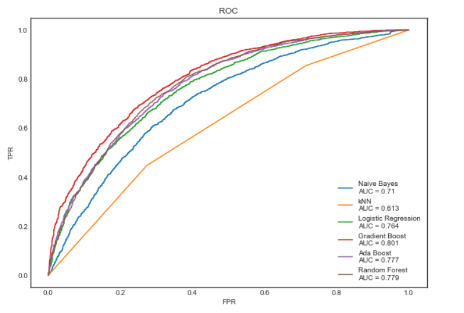

### 2.1 Evaluation of ROC Curve / AUC

- **ROC: Receiver Operating Characteristics**
  - Measure of a classifier’s predictive quality that compares and visualizes the tradeoff between the model’s sensitivity and specificity. Can simultaneously display the two types of errors (**false positive rate** & **true positive rate**) for all possible thresholds.
  - **The true positive rate (TPR) is the sensitivity**: the fraction of recidivised cases within three years that are correctly identified, using a given threshold value.
  - **The false positive rate (FPR) is 1-specificity**: the fraction of non-recidivised cases that we classify incorrectly as recidivised cases, using that same threshold value.
  - The threshold value decreases along the curve from lower left to upper right.
    - When threshold decreases, TPR and FPR increase.
    - When threshold increases, TPR and FPR decrease.
- **AUC: Area Under The Curve**
  - Measure the area under the ROC curve
  - Computation of the relationship between false positives and true positives.
  - Ranges from 0 to 1
  - The worst case would be a random classifier with AUC = 0.5 (diagonal)
  - "As a rule of thumb, an AUC above 0.85 means high classification accuracy, one between 0.75 and 0.85 moderate accuracy, and one less than 0.75 low accuracy" (D' Agostino, Rodgers, & Mauck, 2018)
- **Ideal Case**
  - An ideal ROC curve will stay closer to the top left corner, so the larger area under the curve (AUC), the better the classifier.
- **Model Evaluation**
  - Among the 6 classification models, the Gradient Boosting model yields the highest AUC of 0.801, which is considered to have moderate accuracy, so we pick it as the best model.

## 3. Best Model Performance

```python
# print classification report
print(classification_report(y_test, gb_pred, digits=3))
```

```
              precision    recall  f1-score   support

         0.0      0.733     0.581     0.648      1941
         1.0      0.737     0.847     0.788      2692

    accuracy                          0.736      4633
   macro avg      0.735     0.714     0.718      4633
weighted avg      0.735     0.736     0.729      4633
```

### 3.1 Interpretation of Classification Results from the Best Model

- Since our goal is to use personal information, criminal and supervision history to predict the probability a person will commit new felony/misdemeanor crime within 3 years of parole supervision start date（from the perspective of public safety), we would focus more on **recall related to true positive rate** $Recall = \frac{TP}{TP+FN}$
- In this case, FN is more costly than FP
  - FN: recidivists not classified as recidivists
  - FP: non-recidivists classified as recidivists
  - **FN cases would be a potential threat to public safety if not well addressed. Therefore, we want to increase TP and lower FN**
- Our best model has an accuracy of 73.6% and a recall rate of 84.7%
  - $Accuracy = \frac{TP+TN}{N}$
    - The proportion correctly classified recidivists and non-recidivists by our model on the test data is 73.6%
  - $Recall = \frac{TP}{TP+FN}$
    - Among all recidivists, the proportion of correctly classified recidivists by our model on the test data is 84.7%

We don't discuss precision here because our main discussion is public safety. We would focus more on precision related to the false positive rate if our goal is to prevent wrongful convictions (future discussion).

## 4. Feature Importance

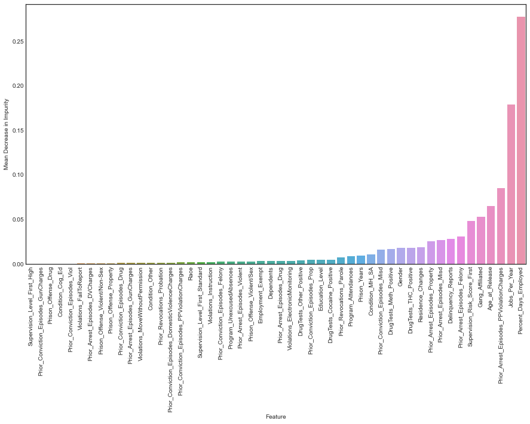

```python
# plot feature importance plot
feature_df = pd.concat([pd.Series(X_train.columns), pd.DataFrame(gb_clf.feature_importances_)], axis=1)
feature_df.columns = ['Feature', 'Mean Decrease in Impurity']
feature_df.sort_values(by = ['Mean Decrease in Impurity'], inplace=True)
plt.figure(figsize=(15, 8))
plt.xticks(rotation=90)
sns.barplot(x= 'Feature', y= 'Mean Decrease in Impurity', data=feature_df)
plt.show()
```

## Answer to Q1

To predict a potential recidivism case and determine the main features associated with recidivism, we explored 6 different classification models. Among them, we chose the Gradient Boosting model as our best model as it yielded the highest AUC of 0.801.

According to our best model, the following TOP 7 important features were associated with recidivism:

- Percent days employeed
- Jobs per year
- Prior arrest episodes PPViolationCharges
- Age at released
- Gang affiliated
- Supervision risk score first
- Prior arrest episodes felony